# Ki-67, 1p36 loss and 9p21/CDKN2A loss as prognostic factors in skull base chordoma

Systematic review and meta-analysis: complete analysis report

Author

Cássio da Silva Minuzzo, Pedro Malfussi Horst, Nicolas de Cesaro Schpchacki, Francisco Martins Lamas, Francisco Ratto Fabris, Erion Junior de Andrade

Published

27 October 2026

This report reproduces every analysis of the systematic review and meta-analysis registered in PROSPERO (CRD420261390460). All pooled estimates, subgroup and sensitivity analyses, small-study-effect tests and forest plots are recomputed from `data/estimates.csv` by `R/meta_analysis.R` each time the report is rendered. The numbers therefore always reflect the current dataset. Tables can be filtered, sorted and copied.

# 1 Main results

| Biomarker | Outcome | Analysis | k | Patients / events | HR (95% CI) | Per 5 points | p | I², % | 95% PI |
| --- | --- | --- | --- | --- | --- | --- | --- | --- | --- |
| Ki-67, binary | Recurrence/progression | Adjusted HRs (primary analysis) | 4 | 246 / 82 + nr in 1 | 2.68 (1.35–5.29) |  | 0.019 | 0 | 1.35–5.29 |
| Ki-67, binary | Recurrence/progression | Unadjusted and derived HRs | 6 | 377 / 145 + nr in 1 | 2.11 (1.00–4.43) |  | 0.050 | 62 | 0.45–9.80 |
| Ki-67, binary | Overall survival | Unadjusted and derived HRs | 6 | 291 / 85 | 2.35 (0.90–6.16) |  | 0.071 | 58 | 0.33–16.86 |
| Ki-67, continuous (per 1 percentage point) | Recurrence/progression | Unadjusted HRs | 10 | 304 / 93 + nr in 1 | 1.13 (1.05–1.22) | 1.85 (1.28–2.67) | 0.004 | 65 | 0.95–1.34 |
| Ki-67, continuous (per 1 percentage point) | Overall survival | Unadjusted HRs | 9 | 299 / 70 | 1.10 (1.02–1.19) | 1.60 (1.08–2.38) | 0.025 | 60 | 0.94–1.29 |

HR, hazard ratio for the higher biomarker category (binary) or per 1 percentage point of Ki-67 (continuous), with values above 1 indicating a worse prognosis. Pooled estimates come from random-effects models (restricted maximum likelihood estimate of τ²) with Hartung–Knapp–Sidik–Jonkman confidence intervals (ad hoc variance correction). PI, prediction interval; nr, not reported. A pooled estimate required at least three independent compatible cohorts; adjusted and unadjusted estimates and binary and continuous scales were never combined.

# 2 Study selection

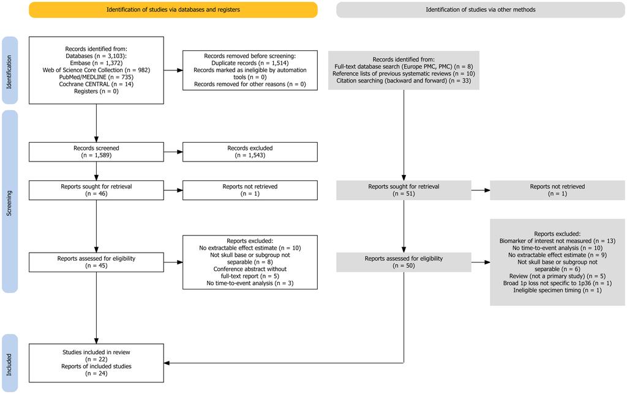

| Step | n | Details |
| --- | --- | --- |
| Records from databases | 3103 |  |
| Records by database | Embase, 1372; Web of Science Core Collection, 982; PubMed/MEDLINE, 735; Cochrane CENTRAL, 14 |  |
| Other methods: full-text database search | 8 | Full-text database search (Europe PMC, PMC) |
| Other methods: reference lists of reviews | 10 | Reference lists of previous systematic reviews |
| Other methods: citation searching | 33 | Citation searching (backward and forward) |
| Duplicates removed | 1514 |  |
| Records screened (title and abstract) | 1589 |  |
| Records excluded | 1543 |  |
| Database reports sought | 46 |  |
| Database reports not retrieved | 1 |  |
| Database reports assessed in full text | 45 |  |
| Database reports excluded (reasons) | No extractable effect estimate, 10; Not skull base or subgroup not separable, 8; Conference abstract without full-text report, 5; No time-to-event analysis, 3 |  |
| Other-methods reports sought | 51 |  |
| Other-methods reports not retrieved | 1 |  |
| Other-methods reports assessed in full text | 50 |  |
| Other-methods reports excluded (reasons) | Biomarker of interest not measured, 13; No time-to-event analysis, 10; No extractable effect estimate, 9; Not skull base or subgroup not separable, 6; Review (not a primary study), 5; Broad 1p loss no… |  |
| Studies included | 22 |  |
| Reports of included studies | 24 |  |

All full-text reports excluded, with reasons:

| Report | Identified via | Reason for exclusion |
| --- | --- | --- |
| Hasegawa 2023 | Databases | Conference abstract without a corresponding full-text report |
| La Corte 2017 | Databases | Conference abstract without a corresponding full-text report |
| Park 2009 | Databases | Conference abstract without a corresponding full-text report |
| Passeri 2026 | Databases | Conference abstract without a corresponding full-text report |
| Yin 2011 | Databases | Conference abstract without a corresponding full-text report |
| Abdallah 2021 | Databases | No extractable effect estimate for a review biomarker |
| Beccaria 2018 | Databases | No extractable effect estimate for a review biomarker |
| Boari 2016 | Databases | No extractable effect estimate for a review biomarker |
| Gersey 2025 | Databases | No extractable effect estimate for a review biomarker |
| Hoppe 2024 | Databases | No extractable effect estimate for a review biomarker |

[output cut: 63 more lines]

# 3 Included studies

| Study | Country; centre(s) | Period; design | Skull base / total, n | Age, years | Children (<18 years), n (%) | Male, n (%) | Histology, conventional / chondroid | Recurrent or previously treated at index surgery | Gross or total resection, n (%) | Radiotherapy, n (%) | Follow-up, months | Review biomarkers |
| --- | --- | --- | --- | --- | --- | --- | --- | --- | --- | --- | --- | --- |
| Matsuno 1997 | Japan; Teikyo University Ichihara Hospital and University of Tokyo Hospital | 1986–1995; retrospective, 2 centres | 10 / 10 | Mean 39.9ᵇ (15–55) | 1 (10.0) | 5 (50.0) | nr | 1 (10.0) radiotherapy before surgery (initial-tumour specimens) | 3 (30.0) | 8 (80.0) | Median 53 (32–118)ᶜ | Ki-67 (MIB-1) |
| Saad 2005 | USA; Cincinnati Children's Hospital Medical Center | 1971–2004; retrospective, 1 centre | 7 / 8ᵃ | Mean 10.3 (7–13)ᵃ | 7 (100)ᵃ | 4 (57.1)ᵃ | nr | 0ᵃ | 3 (42.9)ᵃ | 5 (71.4)ᵃ | Median 21 (3–74)ᵃ | Ki-67 (MIB-1) |
| Sakai 2007 | Japan; Shinshu University Hospital | 1978–2005; retrospective, 1 centre | 11 / 11 | Mean 48.8 (9–71) | 1 (9.1) | 5 (45.5)ᵈ | nr | 0 (initial-surgery specimens) | nr | 6 (54.5) fractionated; radiosurgery in 7 | Mean 153.6 (55.2–343.2) | Ki-67 (MIB-1) |
| Longoni 2008 | Italy; San Raffaele Scientific Institute, Milan | 1997–2005; retrospective, 1 centre (single surgeon) | 15 / 15 | Mean 41 (25–67) | 0 | 10 (66.7) | 9 / 6 | 6 (40.0) previously treated (biopsy elsewhere in 5; radiosurgery in 1) | 0 (near-total 9; subtotal 6) | 15 (100) | Mean 38.9 (7–89) | 1p36 (microsatellite LOH) |
| Ito 2009 | Japan; Fukushima Medical University and Nagoya University (and affiliated hospitals) | 1992–2007; retrospective, consecutive | 19 / 19 | Mean 43.1 (7–75) | 4 (21.1)ᶜ | 11 (57.9) | nr | 0 (primary tumours) | 14 (73.7) | 4 (21.1) | Mean 87.2 (7–165) | Ki-67 (MIB-1) |
| Horbinski 2010 | USA; University of Pittsburgh Medical Center | 1969–2007 (pathology archive); retrospective, 1 centre | 28 / 28 | Median 39 (12–77) | ≥1 | 17 (60.7) | 11 / 17 | 0 (initial resections only) | nr | nr | Median 67 (&lt;1–212) in survivors | Ki-67; 1p36 and 9p21 (FISH, LOH) |
| Kitamura 2013 | Japan; Keio University Hospital | 1993–2011; retrospective, 1 centre | 37 / 37 | Mean 43.6 (10–75) | 6 (16.2)ᶜ | 17 (45.9) | nr | nr | 8 (21.6) | 17 (45.9) | Mean 62.4 (0–146) | Ki-67 (MIB-1); 1p and 9p21 (CGH) |
| Wang L 2014 | China; Beijing Tiantan Hospital | 2006–2011; retrospective, 1 centre (intradural retroclival tumours) | 6 / 6 | Mean 35.8 (22–45)ᶜ | 0 | 5 (83.3) | 6 / 0 | 1 (16.7) recurrent | 3 (50.0) | 2 (33.3) | Mean 58.7 (48–76) in survivors | Ki-67 |
| Yadav 2014 | India; All India Institute of Medical Sciences, New Delhi | 5-year period (dates nr); retrospective, 1 centre | 7 / 22ᵃ | Mean 9.3 (4–18)ᵃ | 6 (85.7)ᵃ | 6 (85.7)ᵃ | 3 / 0 (atypical 3; poorly differentiated 1)ᵃ | 0ᵃ | nr | nr | &lt;1–75 (per case)ᵃ | Ki-67 (MIB-1) |
| Zhai 2017 | China; Beijing Tiantan Hospital | 2007–2014; retrospective, 1 centre | 25 / 25 | Mean 14.4 (8–19) | 25 (100) aged ≤19 yearsᵉ | 10 (40.0) | 24 / 1 | nr | 5 (20.0) | 7 (28.0) | Mean 43.0 (2–108) | Ki-67 |

[output cut: 12 more lines]

Studies are labelled by first author and year (for Ito 2009, Zenonos 2018, Zhai 2019 and Passeri 2022, the year of online publication). Values are n (%) unless stated otherwise; age in years and follow-up in months, reported as median or mean (range) as available. Histology: conventional / chondroid. nr, not reported; ≥1, count not reported but the youngest patient was younger than 18 years; CGH, comparative genomic hybridisation; FISH, fluorescence in situ hybridisation; LOH, loss of heterozygosity; RT, radiotherapy; SRS, stereotactic radiosurgery; TMA, tissue microarray; WGS, whole-genome sequencing.  
ᵃ Skull-base subgroup analysed in this review, computed from individual-participant data (Saad 2005: 7 of 8 cases; Yadav 2014: 7 clival paediatric cases of 22 chordomas).  
ᵇ Mean as reported by the authors (17 tumours from 10 patients); range from the per-patient table.  
ᶜ Computed from individual-participant data published in the article or its supplement.  
ᵈ Reported in the text; the per-patient table lists 4 male patients.  
ᵉ Study definition of paediatric age; the number younger than 18 years was not reported.  
ᶠ The text reports an age range of 17–85 years and a median follow-up of 15.8 years; the per-patient table lists no patient younger than 23 years.  
ᵍ Stated recruitment period; the supplementary data include surgery dates outside it in 6 patients. Follow-up computed from the supplement (stated inclusion criterion: ≥48 months).  
ʰ Tumour samples (primary and recurrent), not patients.  
ⁱ Skull-base subgroup (clival/intradural, 15; clival with extracranial extension, 17) as defined by the authors.  
ʲ Cohort of the survival analysis (patients with primary resection), described in the conference abstract linked to the full-text report (Gersey 2022); the full-text report describes 194 patients and 269 resections from 2001–2020.  
ᵏ Computed from the reported percentage.  
ˡ Computed from the per-patient table. The article reports a ‘median’ age of 45 years and a ‘median’ follow-up of 29.2 months, which are the means of the per-patient table (medians 49 years and 24 months).

## 3.1 Assessment of the biomarkers

| Study | Biomarker | Platform | Antibody or probe | Specimen | n evaluable | Scale and cut-off | Origin of cut-off | Positive, n (%) | Use in the synthesis |
| --- | --- | --- | --- | --- | --- | --- | --- | --- | --- |
| Matsuno 1997 | Ki-67 | IHC | MIB-1 (Immunotech), 1:100 | Whole section; initial resection | 10 (17 tumours) | Continuous, % of nuclei | No cut-off | nr | Unadjusted synthesis: continuous, local recurrence (IPD; Cox) |
| Saad 2005 | Ki-67 | IHC | MIB-1 (Ventana), prediluted | Whole section; resection | 7 (of 8)ᵃ | Continuous, % of nuclei | No cut-off | nr | Unadjusted synthesis: continuous, local recurrence and OS (IPD; Cox) |
| Sakai 2007 | Ki-67 | IHC | MIB-1 (Immunotech) | Whole section; initial resection | 11 | Continuous, % of nuclei | No cut-off | nr | Display: disease-specific survival (IPD; Cox) |
| Longoni 2008 | 1p36 | Microsatellite LOH | 33 markers (1p36.33–1p36.12); matched blood DNA | Tumour tissue; resection | 15 | Binary: LOH present vs absent | Not applicable | 11 (73.3) | Display: PFS and OS (author-provided IPD; Firth) |
| Ito 2009 | Ki-67 | IHC | MIB-1 (supplier nr) | nr; initial resection | 19 | Continuous, per 1 percentage point | ROC-derived 3.44% (log-rank only) | nr | Continuous: unadjusted synthesis; adjusted (display, k=2) |
| Horbinski 2010 | 1p36 | FISH | Vysis LSI 1p36/1q25 dual-colour probe | TMA; initial resection | 23 | Binary: hemizygous deletion in ≥20% of nuclei | Authors' threshold | 4 (17.4) | Display: OS (Tierney method from log-rank p) |
| Horbinski 2010 | 9p21 | FISH | Vysis CDKN2A/CEP9 | TMA; initial resection | 23 | Binary: homozygous deletion in ≥20% of nuclei | Authors' threshold | 5 (21.7) | Display: OS (reconstructed Kaplan–Meier curve) |
| Horbinski 2010 | Ki-67 | IHC | 'ki-55' (Dako), 1:25, as reported | TMA; initial resection | 25 | Binary, ≥5% | Authors' threshold | 8 (32.0) | Unadjusted synthesis: binary, OS (reconstructed Kaplan–Meier curve) |
| Kitamura 2013 | 1p (covering 1p36) | Conventional metaphase CGH | Not applicable | FFPE, microdissected; resection | 37 | Binary: loss covering 1p36 (whole 1p arm in 5; 1p31–pter in 1) | Not applicable | 6 (16.2) | Sensitivity only (broad 1p loss): PFS and OS (IPD) |
| Kitamura 2013 | 9p21 | Conventional metaphase CGH | Not applicable | FFPE, microdissected; resection | 37 | Binary: loss covering 9p21 (chromosome 9 in 3, 9p arm in 1, 9p21–23 in 1); zygosity not determinable | Not applicable | 5 (13.5) | Display: PFS and OS (IPD) |

[output cut: 21 more lines]

One row per study–biomarker pair measured. CGH, comparative genomic hybridisation; DFS, disease-free survival; FFPE, formalin-fixed paraffin-embedded; FISH, fluorescence in situ hybridisation; IHC, immunohistochemistry; IPD, individual-participant data; LOH, loss of heterozygosity; nr, not reported; OS, overall survival; PFS, progression-free survival; RFS, recurrence-free survival; ROC, receiver operating characteristic; TMA, tissue microarray; WGS, whole-genome sequencing.  
Specimen: tissue format (whole section or TMA) as described in the article, then the surgery that provided the specimen; nr, not described.  
Primary synthesis: adjusted hazard ratios only. Unadjusted synthesis: unadjusted, derived and IPD-based estimates. Display: forest plot without a pooled estimate (k<3 or incompatible estimates).  
ᵃ Skull-base cases only.  
ᵇ Genetic group (1p36 and 9p21) unknown in 38 of 110 patients; the number with FISH results was not reported.  
ᶜ Estimates published in the conference abstract (Gersey 2022) linked to the full-text report.

# 4 All extracted and derived estimates

Every eligible hazard ratio, with its source and its use in the syntheses (94 estimates from 22 studies).

| Study | Biomarker | Outcome | Comparison | Adjustment | n | Events | HR (95% CI) | Source | Use in the synthesis | Synthesis ID | Estimate ID |
| --- | --- | --- | --- | --- | --- | --- | --- | --- | --- | --- | --- |
| Matsuno 1997 | Ki-67 | Recurrence/progression | Continuous, per 1 percentage point | Unadjusted | 10 | 3 | 1.21 (0.98–1.49) | Our Cox model on individual data | Unadjusted synthesis | KI67-CONT-PFS-UNADJ | CHO-14-KI67-LRLP-IPD |
| Matsuno 1997 | Ki-67 | Recurrence/progression | Binary, ≥5% vs &lt;5% (dichotomised by the reviewers) | Unadjusted | 10 | 3 | 12.43 (1.10–1712.33) | Our Cox model on individual data | Not used: cut-off chosen by the reviewers (the continuous estimate was used) |  | CHO-14-KI67-LRLP-IPD-BIN |
| Saad 2005 | Ki-67 | Overall survival | Continuous, per 1 percentage point | Unadjusted | 7 | 5 | 1.01 (0.97–1.04) | Our Cox model on individual data | Unadjusted synthesis | KI67-CONT-OS-UNADJ | CHO-21-KI67-OS-IPD |
| Saad 2005 | Ki-67 | Recurrence/progression | Continuous, per 1 percentage point | Unadjusted | 6 | 4 | 1.02 (0.97–1.06) | Our Cox model on individual data | Unadjusted synthesis | KI67-CONT-PFS-UNADJ | CHO-21-KI67-LRLP-IPD |
| Sakai 2007 | Ki-67 | Disease-specific survival | Binary, ≥5% vs &lt;5% (dichotomised by the reviewers) | Unadjusted | 11 | 4 | 1.82 (0.16–20.51) | Our Cox model on individual data | Not used: cut-off chosen by the reviewers (the continuous estimate was used) |  | CHO-22-KI67-OS-IPD-BIN |
| Sakai 2007 | Ki-67 | Disease-specific survival | Continuous, per 1 percentage point | Unadjusted | 11 | 4 | 1.13 (0.89–1.44) | Our Cox model on individual data | Displayed, not pooled | KI67-CONT-DSS-DISPLAY | CHO-22-KI67-OS-IPD |
| Longoni 2008 | 1p36 | Overall survival | LOH present vs absent (33 microsatellite markers) | Unadjusted | 15 | 3 | 1.74 (0.16–237.60) | Our Cox model (Firth) on author-provided data | Displayed, not pooled | 1P36-OS-DISPLAY | CHO-13-1P36-OS-IPD |
| Longoni 2008 | 1p36 | Recurrence/progression | LOH present vs absent (33 microsatellite markers) | Unadjusted | 15 | 4 | 3.35 (0.35–444.70) | Our Cox model (Firth) on author-provided data | Displayed, not pooled | 1P36-PFS-DISPLAY | CHO-13-1P36-PFS-IPD |
| Ito 2009 | Ki-67 | Recurrence/progression | Continuous, per 1 percentage point | Adjusted (4 covariates) | 19 | 11 | 1.34 (1.00–1.80) | Reported | Displayed, not pooled | KI67-CONT-PFS-ADJ | CHO-09-KI67-PFS-MV |
| Ito 2009 | Ki-67 | Recurrence/progression | Continuous, per 1 percentage point | Unadjusted | 19 | 11 | 1.31 (1.02–1.68) | Reported | Unadjusted synthesis | KI67-CONT-PFS-UNADJ | CHO-09-KI67-PFS-UV |

[output cut: 84 more lines]

# 5 Meta-analyses

## 5.1 Summary of all syntheses

| Biomarker | Outcome | Analysis | k | Patients | Events | HR (95% CI) | I², % | Note | Studies | Synthesis ID |
| --- | --- | --- | --- | --- | --- | --- | --- | --- | --- | --- |
| Ki-67, binary | Recurrence/progression | Adjusted HRs (primary analysis) | 4 | 246 | 82 | 2.68 (1.35–5.29) | 0 |  | Kitamura 2013; Zhang S 2019; Passeri 2022; Wang B 2022 | KI67-BIN-PFS-ADJ |
| Ki-67, binary | Overall survival | Adjusted HRs | 2 | 75 | 21 | Not pooled |  | k = 2 (fewer than 3 cohorts) | Wang B 2022; Noya 2023 | KI67-BIN-OS-ADJ |
| Ki-67, binary | Recurrence/progression | Unadjusted and derived HRs | 6 | 377 | 145 | 2.11 (1.00–4.43) | 62 |  | Kitamura 2013; Zhang S 2019; Passeri 2022; Noya 2023; Righi 2023; Zhao 2023 | KI67-BIN-PFS-UNADJ |
| Ki-67, binary | Overall survival | Unadjusted and derived HRs | 6 | 291 | 85 | 2.35 (0.90–6.16) | 58 |  | Horbinski 2010; Kitamura 2013; Zhang S 2019; Noya 2023; Righi 2023; Zhao 2023 | KI67-BIN-OS-UNADJ |
| Ki-67, continuous (per 1 percentage point) | Recurrence/progression | Adjusted HRs | 2 | 113 | 60 | Not pooled |  | k = 2 (fewer than 3 cohorts) | Ito 2009; Zhao 2023 | KI67-CONT-PFS-ADJ |
| Ki-67, continuous (per 1 percentage point) | Overall survival | Adjusted HRs | 2 | 204 | 44 | Not pooled |  | k = 2 (fewer than 3 cohorts) | Zhao 2023; Muthiah 2026 | KI67-CONT-OS-ADJ |
| Ki-67, continuous (per 1 percentage point) | Recurrence/progression | Unadjusted HRs | 10 | 304 | 93 | 1.13 (1.05–1.22) | 65 |  | Matsuno 1997; Saad 2005; Ito 2009; Kitamura 2013; Wang L 2014; Yadav 2014; Zenonos 2018; Cha 2019; Noya 2023; Righi 2023 | KI67-CONT-PFS-UNADJ |
| Ki-67, continuous (per 1 percentage point) | Overall survival | Unadjusted HRs | 9 | 299 | 70 | 1.10 (1.02–1.19) | 60 |  | Saad 2005; Kitamura 2013; Wang L 2014; Yadav 2014; Cha 2019; Chen 2022; Noya 2023; Righi 2023; Muthiah 2026 | KI67-CONT-OS-UNADJ |
| Ki-67, continuous (per 1 percentage point) | Disease-specific survival | Display | 2 | 76 | 20 | Not pooled |  | Display only (incompatible scales, platforms or outcomes) | Sakai 2007; Righi 2023 | KI67-CONT-DSS-DISPLAY |
| Ki-67, binary | Disease-specific survival | Display | 1 | 226 | 0 | Not pooled |  | Display only (incompatible scales, platforms or outcomes) | Passeri 2022; Passeri 2022 | KI67-BIN-DSS-DISPLAY |

[output cut: 7 more lines]

## 5.2 Forest plots

Squares, study estimates (size proportional to weight in pooled syntheses); horizontal lines, 95% confidence intervals as reported or computed from the standard error; diamond, pooled estimate; dashed line, 95% prediction interval. Source: Reported, HR and 95% CI reported by the authors; CI from p, CI derived from the reported p value; IPD, Cox model fitted to individual patient data (Firth’s correction when all events occurred in one group); KM curve, reconstructed Kaplan–Meier curve; Log-rank, derived from the log-rank p value and events (Tierney method).

### 5.2.1 Ki-67, binary: recurrence/progression – Adjusted HRs (primary analysis)

Pooled HR 2.68 (1.35–5.29); p = 0.019; I² = 0%; τ² = 0.0000; 95% prediction interval 1.35–5.29.

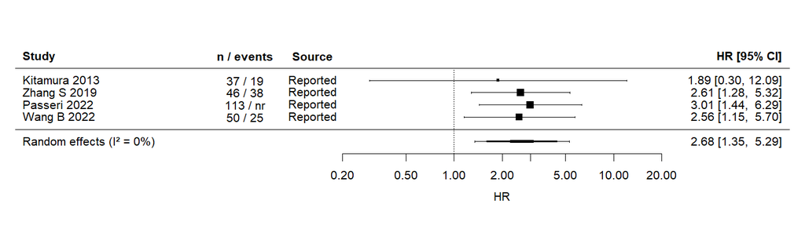

### 5.2.2 Ki-67, binary: overall survival – Adjusted HRs

No pooled estimate: k = 2 (fewer than 3 cohorts).

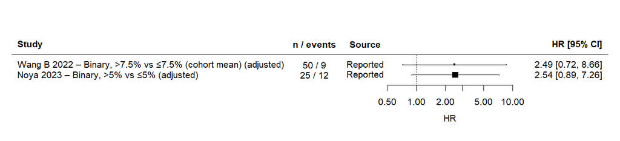

### 5.2.3 Ki-67, binary: recurrence/progression – Unadjusted and derived HRs

Pooled HR 2.11 (1.00–4.43); p = 0.050; I² = 62%; τ² = 0.2737; 95% prediction interval 0.45–9.80.

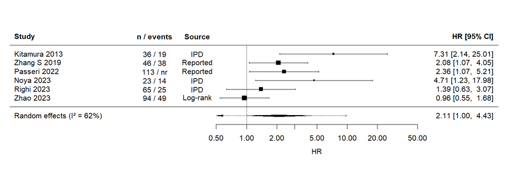

### 5.2.4 Ki-67, binary: overall survival – Unadjusted and derived HRs

Pooled HR 2.35 (0.90–6.16); p = 0.071; I² = 58%; τ² = 0.4471; 95% prediction interval 0.33–16.86.

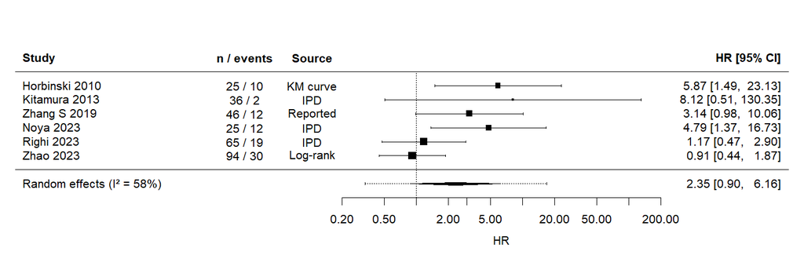

### 5.2.5 Ki-67, continuous (per 1 percentage point): recurrence/progression – Adjusted HRs

No pooled estimate: k = 2 (fewer than 3 cohorts).

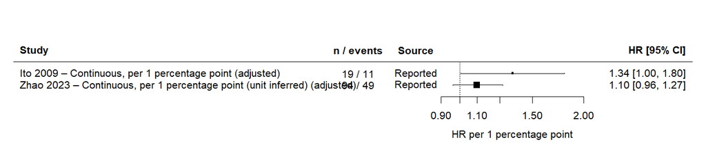

### 5.2.6 Ki-67, continuous (per 1 percentage point): overall survival – Adjusted HRs

No pooled estimate: k = 2 (fewer than 3 cohorts).

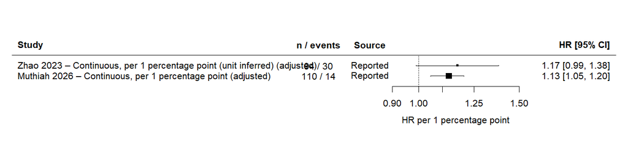

### 5.2.7 Ki-67, continuous (per 1 percentage point): recurrence/progression – Unadjusted HRs

Pooled HR 1.13 (1.05–1.22); p = 0.004; I² = 65%; τ² = 0.0047; 95% prediction interval 0.95–1.34; per 5 percentage points 1.85 (1.28–2.67).

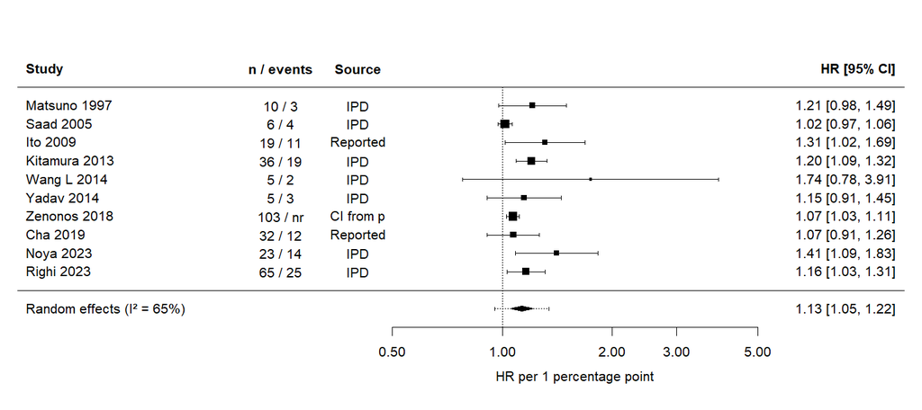

### 5.2.8 Ki-67, continuous (per 1 percentage point): overall survival – Unadjusted HRs

Pooled HR 1.10 (1.02–1.19); p = 0.025; I² = 60%; τ² = 0.0037; 95% prediction interval 0.94–1.29; per 5 percentage points 1.60 (1.08–2.38).

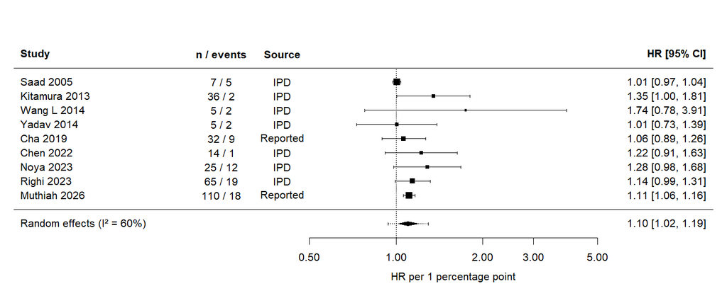

### 5.2.9 Ki-67, continuous (per 1 percentage point): disease-specific survival – Display

No pooled estimate: Display only (incompatible scales, platforms or outcomes).

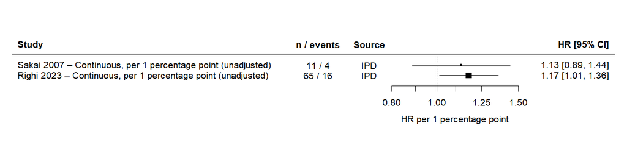

### 5.2.10 Ki-67, binary: disease-specific survival – Display

No pooled estimate: Display only (incompatible scales, platforms or outcomes).

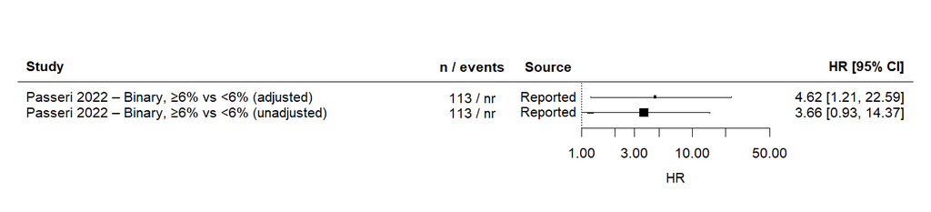

### 5.2.11 Ki-67, H-score (per unit, 0-300): recurrence/progression – Display

No pooled estimate: Display only (incompatible scales, platforms or outcomes).

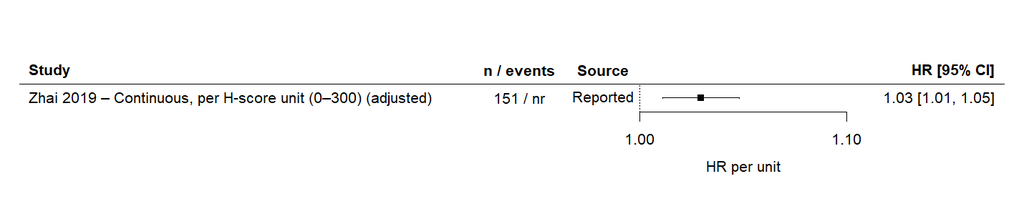

### 5.2.12 Ki-67, ordinal categories: recurrence/progression – Display

No pooled estimate: Display only (incompatible scales, platforms or outcomes).

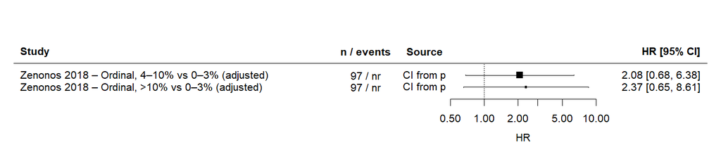

### 5.2.13 Ki-67, 1p36 and 9p21 (Zenonos 2018): progression after radiotherapy – Display

No pooled estimate: Display only (incompatible scales, platforms or outcomes).

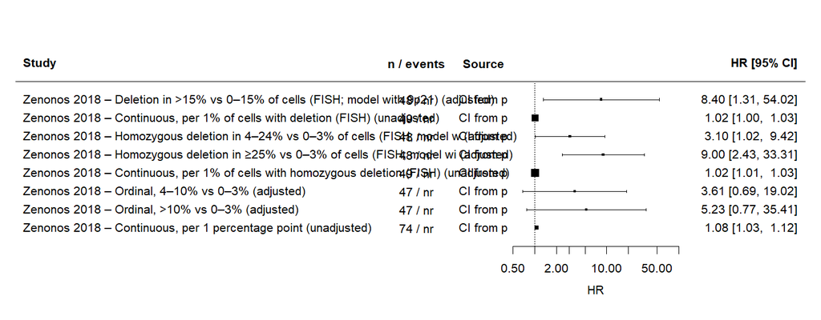

### 5.2.14 1p36 loss: recurrence/progression – Display

No pooled estimate: Display only (incompatible scales, platforms or outcomes).

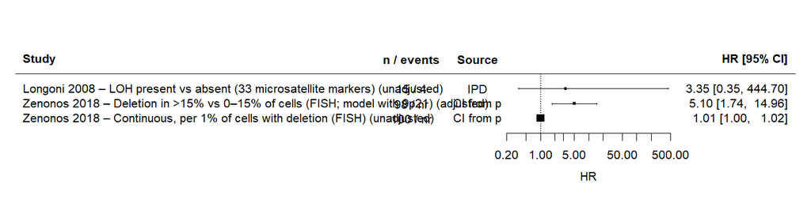

### 5.2.15 1p36 loss: overall survival – Display

No pooled estimate: Display only (incompatible scales, platforms or outcomes).

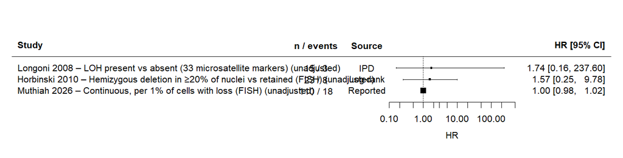

### 5.2.16 9p21/CDKN2A loss: recurrence/progression – Display

No pooled estimate: Display only (incompatible scales, platforms or outcomes).

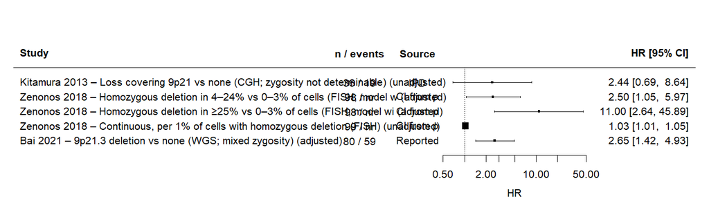

### 5.2.17 9p21/CDKN2A loss: overall or disease-specific survival – Display

No pooled estimate: Display only (incompatible scales, platforms or outcomes).

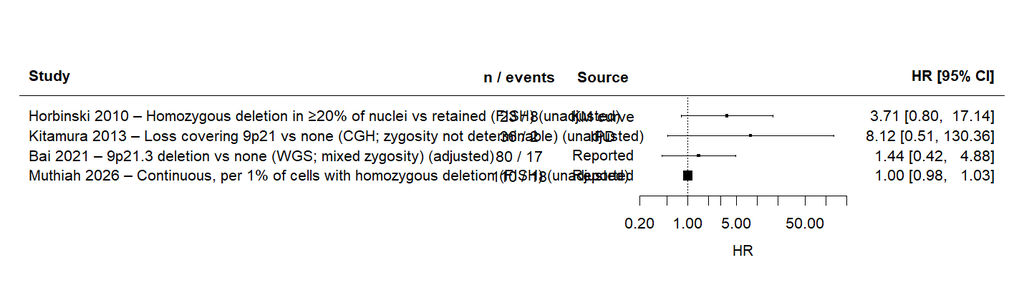

# 6 Subgroup analysis by Ki-67 cut-off

Binary Ki-67, unadjusted and derived HRs; cut-offs around 5% (4–6%) versus other values, tested with random-effects meta-regression. Subgroups with fewer than three cohorts are described without inference. The adjusted (primary) synthesis was not divided, because only one cohort used a cut-off outside 4–6%.

| Synthesis | Subgroup | k | HR (95% CI) | I², % | p for subgroup difference | Note | Studies |
| --- | --- | --- | --- | --- | --- | --- | --- |
| Recurrence/progression | Cut-off around 5% (4–6%) | 4 | 2.90 (1.23–6.81) | 16 | 0.052 |  | Kitamura 2013; Zhang S 2019; Passeri 2022; Noya 2023 |
| Recurrence/progression | Other cut-offs | 2 | 1.09 (0.06–21.10) | 0 | 0.052 | Fewer than three cohorts: described without inference | Righi 2023; Zhao 2023 |
| Overall survival | Cut-off around 5% (4–6%) | 4 | 4.49 (1.44–13.98) | 0 | 0.031 |  | Horbinski 2010; Kitamura 2013; Zhang S 2019; Noya 2023 |
| Overall survival | Other cut-offs | 2 | 1.01 (0.03–38.61) | 0 | 0.031 | Fewer than three cohorts: described without inference | Righi 2023; Zhao 2023 |

# 7 Sensitivity analyses

| Synthesis | Analysis | k | HR (95% CI) | I², % |
| --- | --- | --- | --- | --- |
| Ki-67, binary, recurrence/progression – Adjusted HRs (primary analysis) | Main analysis (REML, Hartung–Knapp–Sidik–Jonkman) | 4 | 2.68 (1.35–5.29) | 0 |
| Ki-67, binary, recurrence/progression – Adjusted HRs (primary analysis) | DerSimonian–Laird estimator of τ² | 4 | 2.68 (1.35–5.29) | 0 |
| Ki-67, binary, recurrence/progression – Adjusted HRs (primary analysis) | Paule–Mandel estimator of τ² | 4 | 2.68 (1.35–5.29) | 0 |
| Ki-67, binary, recurrence/progression – Adjusted HRs (primary analysis) | Leave-one-out: without Kitamura 2013 | 3 | 2.73 (1.06–7.02) | 0 |
| Ki-67, binary, recurrence/progression – Adjusted HRs (primary analysis) | Leave-one-out: without Zhang S 2019 | 3 | 2.71 (0.87–8.49) | 0 |
| Ki-67, binary, recurrence/progression – Adjusted HRs (primary analysis) | Leave-one-out: without Passeri 2022 | 3 | 2.53 (0.82–7.77) | 0 |
| Ki-67, binary, recurrence/progression – Adjusted HRs (primary analysis) | Leave-one-out: without Wang B 2022 | 3 | 2.72 (0.92–8.04) | 0 |
| Ki-67, binary, recurrence/progression – Adjusted HRs (primary analysis) | Excluding cohorts with &lt;20 participants or &lt;10 events | 4 | 2.68 (1.35–5.29) | 0 |
| Ki-67, binary, recurrence/progression – Adjusted HRs (primary analysis) | Directly reported estimates only | 4 | 2.68 (1.35–5.29) | 0 |
| Ki-67, binary, recurrence/progression – Adjusted HRs (primary analysis) | Excluding data-derived cut-offs (mean, median or ROC) | 2 | Not pooled (k = 2) | – |

[output cut: 79 more lines]

# 8 Small-study effects

Assessed only in syntheses with at least 10 cohorts: contour-enhanced funnel plot (contours at p = 0.10, 0.05 and 0.01) and Egger’s regression test with the standard error as predictor; the limit estimate is the predicted HR as the standard error tends to zero.

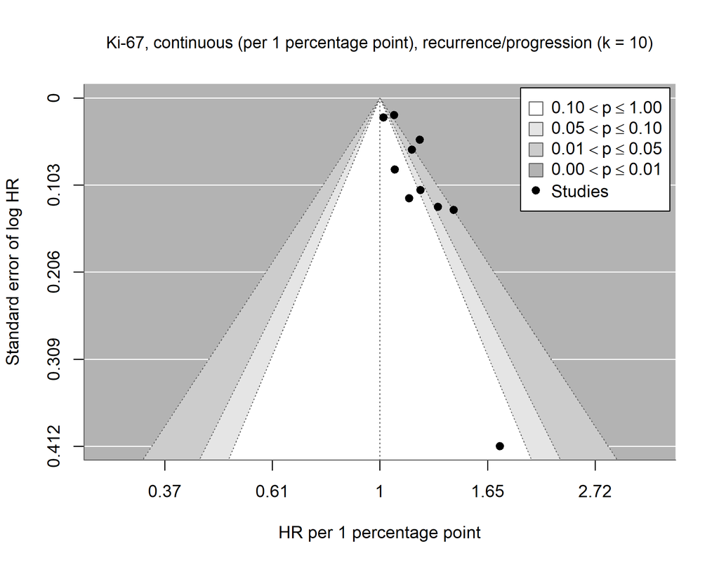

| Synthesis | k | Egger z | Egger p | Limit estimate (95% CI) |
| --- | --- | --- | --- | --- |
| Ki-67, continuous (per 1 percentage point), recurrence/progression – Unadjusted HRs | 10 | 2.99 | 0.017 | 1.02 (0.95–1.10) |

# 9 Risk of bias (QUIPS)

Each combination of study, biomarker and estimate class was assessed in six domains. Unadjusted estimates are at high risk for D5 (confounding) by rule, and their overall rating is computed without D5.

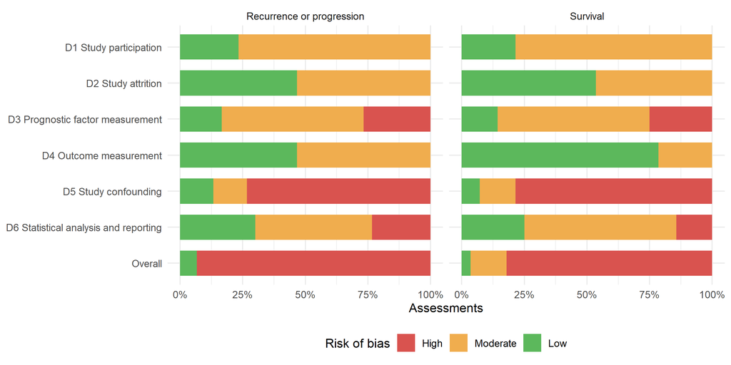

## 9.1 Ratings of each assessment

| Assessment | D1 | D2 | D3 | D4 recurrence | D4 survival | D5 | D6 recurrence | D6 survival | Overall recurrence | Overall survival |
| --- | --- | --- | --- | --- | --- | --- | --- | --- | --- | --- |
| Kitamura 2013, Ki-67 (adjusted) | moderate | low | moderate | moderate | – | low | high | – | high | – |
| Kitamura 2013, Ki-67 (unadjusted) | moderate | low | moderate | moderate | low | high | low | low | high | moderate |
| Kitamura 2013, 9p21/CDKN2A (unadjusted) | moderate | low | moderate | moderate | low | high | low | low | high | moderate |
| Kitamura 2013, Broad 1p loss (unadjusted) | moderate | low | moderate | moderate | low | high | low | low | high | moderate |
| Longoni 2008, 1p36 (unadjusted) | moderate | low | moderate | low | low | high | moderate | moderate | high | high |
| Horbinski 2010, Ki-67 (unadjusted) | moderate | low | moderate | – | low | high | – | moderate | – | high |
| Horbinski 2010, 1p36 (unadjusted) | moderate | low | moderate | – | low | high | – | moderate | – | high |
| Horbinski 2010, 9p21/CDKN2A (unadjusted) | moderate | low | moderate | – | low | high | – | moderate | – | high |
| Zenonos 2018, Ki-67 (adjusted) | moderate | moderate | high | low | – | high | high | – | high | – |
| Zenonos 2018, Ki-67 (unadjusted) | moderate | moderate | moderate | low | – | high | moderate | – | high | – |

[output cut: 30 more lines]

## 9.2 Justification of each judgement

| Assessment | D1 | D2 | D3 | D4 | D5 | D6 |
| --- | --- | --- | --- | --- | --- | --- |
| Kitamura 2013, Ki-67 (adjusted) | Single-centre retrospective series (Keio, 1993–2011) of all 37 operated skull base chordomas; consecutive inclusion not stated; population described case by case in the supplement (SDC2). | No loss to follow-up; mean follow-up 62.4 months (0–146); complete individual data in SDC2. | MIB-1 (Dako 1:200) on whole sections, &gt;1000 cells from &gt;3 areas of typical appearance; 5% cut-off taken from the literature; specimen origin (primary or recurrence) and blinding not reported. | PFS defined from the initial surgery to the first day of treatment of the recurrence (event dated by a treatment proxy); follow-up MRI schedule not described. | Adjusted for sex, extent of resection and postoperative irradiation (plus 1p loss, 1q and 2p gains and brachyury). | 7 covariates for 19 events (EPV ~2.7): severe overfitting; covariates selected by univariable significance; two alternative models published (brachyury by immunohistochemistry or T-gene FISH). |
| Kitamura 2013, Ki-67 (unadjusted) | Single-centre retrospective series (Keio, 1993–2011) of all 37 operated skull base chordomas; consecutive inclusion not stated; population described case by case in the supplement (SDC2). | No loss to follow-up; mean follow-up 62.4 months (0–146); complete individual data in SDC2. | MIB-1 (Dako 1:200), &gt;1000 cells from &gt;3 areas; 5% cut-off from the literature and continuous scale from the individual data; specimen origin and blinding not reported. | PFS defined from the initial surgery to the first day of treatment of the recurrence (event dated by a treatment proxy); follow-up MRI schedule not described. / Death and follow-up per patient in SDC2… | Unadjusted estimate: confounding by extent of resection, radiotherapy and age not controlled (assessment rule). | Reanalysis of the individual data in SDC2 (n = 36; case 1 without time at risk); the recomputed log-rank test reproduces the published one (0.0002 vs &lt;0.001); Cox model without separation. |
| Kitamura 2013, 9p21/CDKN2A (unadjusted) | Single-centre retrospective series (Keio, 1993–2011) of all 37 operated skull base chordomas; consecutive inclusion not stated; population described case by case in the supplement (SDC2). | No loss to follow-up; mean follow-up 62.4 months (0–146); complete individual data in SDC2. | Conventional metaphase CGH (resolution about 10 Mb): 9p21 loss inferred from broad losses (3 of 5 from loss of the whole chromosome 9); zygosity not determinable; specimen origin not reported. | PFS defined from the initial surgery to the first day of treatment of the recurrence (event dated by a treatment proxy); follow-up MRI schedule not described. / Death and follow-up per patient in SDC2… | Unadjusted estimate: confounding by extent of resection, radiotherapy and age not controlled (assessment rule). | Reanalysis of the individual data in SDC2; recomputed log-rank 0.1497 vs 0.150 published. |
| Kitamura 2013, Broad 1p loss (unadjusted) | Single-centre retrospective series (Keio, 1993–2011) of all 37 operated skull base chordomas; consecutive inclusion not stated; population described case by case in the supplement (SDC2). | No loss to follow-up; mean follow-up 62.4 months (0–146); complete individual data in SDC2. | Conventional CGH: 1p loss covering 1p36 by whole-arm loss (5) or 1p31–pter (1), not focal loss; zygosity undetermined; specimen origin not reported. | PFS defined from the initial surgery to the first day of treatment of the recurrence (event dated by a treatment proxy); follow-up MRI schedule not described. / Death and follow-up per patient in SDC2… | Unadjusted estimate: confounding by extent of resection, radiotherapy and age not controlled (assessment rule). | Reanalysis of the individual data in SDC2. |
| Longoni 2008, 1p36 (unadjusted) | Single centre (San Raffaele, 1997–2005), 15 patients operated on by the same surgeon; consecutive inclusion not stated; subset of the Boari 2016 series. | No losses; CT and MRI every 3 months and then every 6 months; mean follow-up 38.9 months (7–89). | LOH by 33 microsatellite markers of 1p36 (valid method), but mixed specimens: 6 of 15 previously treated (prior biopsy or radiosurgery); LOH includes copy-neutral loss; blinding not reported. | Progression on CT/MRI within a defined protocol; death from any cause. | Unadjusted estimate: confounding by extent of resection, radiotherapy and age not controlled (assessment rule). | Individual data provided by the authors with internal inconsistencies (2 cases with progression-free interval longer than follow-up); complete separation (4 of 4 events in the LOH group), handled with… |
| Horbinski 2010, Ki-67 (unadjusted) | Archive cases (Pittsburgh, 1969–2007) with tissue available for TMA; consecutive inclusion not stated; population described. | 1 of 28 lost to follow-up; median follow-up 67 months in survivors (&lt;1–212). | Clone ki-55 (not MIB-1) on 0.6-mm TMA cores in triplicate; 50% of blocks decalcified (degrades the antigen); evaluable in 25 of 28; 5% cut-off set in advance by the authors; two observers; index-opera… | Overall survival from any cause with documented follow-up (PFS not assessed). | Unadjusted estimate: confounding by extent of resection, radiotherapy and age not controlled (assessment rule). | HR reconstructed from the Kaplan–Meier curve (Figure 3A), validated by the log-rank test (0.0049 vs 0.005); the authors report only the p value. |
| Horbinski 2010, 1p36 (unadjusted) | Archive cases (Pittsburgh, 1969–2007) with tissue available for TMA; consecutive inclusion not stated; population described. | 1 of 28 lost to follow-up; median follow-up 67 months in survivors (&lt;1–212). | FISH LSI 1p36, hemizygous deletion in ≥20% of nuclei (threshold from normal controls, set in advance); 50% of blocks decalcified; low agreement with LOH (6 of 8 with 1p LOH had no 1p36 deletion); eval… | Overall survival from any cause. | Unadjusted estimate: confounding by extent of resection, radiotherapy and age not controlled (assessment rule). | Estimate derived from the log-rank p value (Tierney method) with an assumed number of events per group (curve not published); sensitivity analyses assuming 7 and 10 deaths (8 in the main analysis). |
| Horbinski 2010, 9p21/CDKN2A (unadjusted) | Archive cases (Pittsburgh, 1969–2007) with tissue available for TMA; consecutive inclusion not stated; population described. | 1 of 28 lost to follow-up; median follow-up 67 months in survivors (&lt;1–212). | FISH CDKN2A, homozygous deletion in ≥20% of nuclei (set in advance); 190-kb commercial probe; 50% of blocks decalcified; 3 of 5 homozygous deletions without 9p LOH; evaluable in 23 of 28. | Overall survival from any cause. | Unadjusted estimate: confounding by extent of resection, radiotherapy and age not controlled (assessment rule). | HR reconstructed from Figure 3C (recomputed log-rank 0.073 vs 0.083 published). |
| Zenonos 2018, Ki-67 (adjusted) | Single centre (UPMC, 11/2007–04/2016), 105 clival tumours, with prospective validation of the panel; consecutive inclusion not stated; 58 of 105 (55%) operated for recurrence. | Follow-up duration, losses and number of events not reported. | Ordinal strata (0–3%, 4–10%, &gt;10%) defined by optimisation on the study data (several cut-offs tested in log-rank tests); tissue format not stated for immunohistochemistry (FISH was done on TMA); h… | Radiological progression after surgery, with case-by-case review of MRI, including external images. | Adjusted only for other markers (9p21, 1p36, 1q25); no extent of resection or radiotherapy. | HRs published without CI or number of events (CI derived from a rounded p value); strata optimised on the data; the author confirmed that raw data are not available. |
| Zenonos 2018, Ki-67 (unadjusted) | Single centre (UPMC, 11/2007–04/2016), 105 clival tumours, with prospective validation of the panel; consecutive inclusion not stated; 58 of 105 (55%) operated for recurrence. | Follow-up duration, losses and number of events not reported. | Continuous scale (per 1%), no cut-off; tissue format not stated for immunohistochemistry (FISH was done on TMA); hotspot, 2 observers; mixed specimens (55% recurrences). | Radiological progression after surgery, with case-by-case review of MRI, including external images. | Unadjusted estimate: confounding by extent of resection, radiotherapy and age not controlled (assessment rule). | Supplementary Table 1: HR and p without CI; p censored at &lt;0.001 requires a conservative standard error; events not reported. |

[output cut: 30 more lines]

Tables and figures cited in the justifications are those of the source article.

# 10 Certainty of evidence (GRADE)

## 10.1 Summary of findings

| Biomarker (scale) | Outcome | Analysis | k (patients / events) | HR (95% CI) | Heterogeneity | Reasons for downgrading | Certainty | Summary statement |
| --- | --- | --- | --- | --- | --- | --- | --- | --- |
| Ki-67, binary (cut-offs 5–7.5%) | Recurrence/progression | Primary: adjusted HRs | 4 (246 / 82 + nr in 1) | 2.68 (1.35–5.29) | I² 0%; PI 1.35–5.29 | Risk of bias −1; imprecision −1 | LOW | High Ki-67 may be associated with a higher risk of recurrence or progression. |
| Ki-67, binary (cut-offs 5–7.5%) | Overall survival | Primary: adjusted HRs | 2 (75 / 21) | Not pooled (k=2): Noya 2.54 (0.89–7.26); Wang B 2.49 (0.72–8.66) | Not applicable | Risk of bias −1; imprecision −2 | VERY LOW | The evidence is very uncertain. |
| Ki-67, binary (cut-off 6%) | Disease-specific survivalᵃ | Display (k=1) | 1 (113 / nr) | Passeri: adjusted 4.62 (1.21–22.59); unadjusted 3.66 (0.93–14.37) | Not applicable | Risk of bias −1; imprecision −2 | VERY LOW | The evidence is very uncertain. |
| Ki-67, continuous (per 1 percentage point) | Recurrence/progression | Primary: adjusted HRs | 2 (113 / 60) | Not pooled (k=2): Ito 1.34 (1.00–1.80); Zhao 1.10 (0.96–1.27) | Not applicable | Risk of bias −1; imprecision −2 | VERY LOW | The evidence is very uncertain. |
| Ki-67, continuous (per 1 percentage point) | Overall survival | Primary: adjusted HRs | 2 (204 / 44) | Not pooled (k=2): Zhao 1.17 (0.99–1.38); Muthiah 1.13 (1.05–1.20)ᵈ | Not applicable | Risk of bias −1; imprecision −2 | VERY LOW | The evidence is very uncertain. |
| Ki-67, binary (cut-offs 2–6%) | Recurrence/progression | Unadjusted and derived HRs | 6 (377 / 145 + nr in 1) | 2.11 (1.00–4.43) | I² 62%; PI 0.45–9.80 | Risk of bias −1; inconsistency −1; imprecision −1 | VERY LOW | The evidence is very uncertain; the association appears confined to cut-offs around 5%. |
| Ki-67, binary (cut-offs 2–5.08%) | Overall survival | Unadjusted and derived HRs | 6 (291 / 85) | 2.35 (0.90–6.16) | I² 58%; PI 0.33–16.86 | Risk of bias −1; inconsistency −1; imprecision −1 | VERY LOW | The evidence is very uncertain. |
| Ki-67, continuous (per 1 percentage point) | Recurrence/progression | Unadjusted HRs | 10 (304 / 93 + nr in 1) | 1.13 (1.05–1.22); per 5 points 1.85 (1.28–2.67) | I² 65%; PI 0.95–1.34 | Risk of bias −1; inconsistency −1; publication bias −1 | VERY LOW | The evidence is very uncertain; small studies showed larger effects. |
| Ki-67, continuous (per 1 percentage point) | Overall survival | Unadjusted HRs | 9 (299 / 70) | 1.10 (1.02–1.19); per 5 points 1.60 (1.08–2.38) | I² 60%; PI 0.94–1.29 | Risk of bias −1; inconsistency −1 | LOW | Higher Ki-67 may be associated with worse overall survival. |
| Ki-67, continuous (per 1 percentage point) | Disease-specific survival | Display (k=2) | 2 (76 / 20) | Not pooled: Sakai 1.13 (0.89–1.44); Righi 1.17 (1.01–1.36) | Not applicable | Risk of bias −1; imprecision −2 | VERY LOW | The evidence is very uncertain. |

[output cut: 5 more lines]

HR, hazard ratio for the higher biomarker category (binary) or per 1 percentage point (continuous); pooled estimates from random-effects models (REML) with Hartung-Knapp-Sidik-Jonkman confidence intervals (ad hoc variance correction); PI, 95% prediction interval. k, number of cohorts; n, patients; nr, not reported. Certainty of evidence rated with GRADE for prognostic factors; statements follow GRADE informative-statement guidance (low certainty, ‘may’; very low certainty, ‘the evidence is very uncertain’).  
ᵃ The study’s ‘overall survival’ censored deaths from surgical complications or causes unrelated to the disease.  
ᵇ 95% CI derived from the reported p value.  
ᶜ Hazard ratios relative to 0–3% of cells with homozygous deletion; CIs not reported.  
ᵈ Estimates published in the conference abstract (Gersey 2022) linked to the full-text report (Muthiah 2026).  
ᵉ Muthiah 2026: number of patients with FISH results not reported; the cohort of 110 patients and its 18 deaths are counted.

## 10.2 Evidence profile

| Comparison | Starting certainty | Risk of bias | Inconsistency | Indirectness | Imprecision | Publication bias | Upgrading | Certainty |
| --- | --- | --- | --- | --- | --- | --- | --- | --- |
| Ki-67 binary, recurrence/progression, adjusted (primary) | High | Serious (−1): all 4 studies at high risk (Kitamura, 7 covariates for 19 events; Wang B, method not described and cut-off at cohort mean; Zhang S, cut-off at median and no adjustment for radiotherapy; … | Not serious (I² 0%; PI 1.35–5.29) | Not serious (all skull base; IHC; cut-offs 5–7.5%) | Serious (−1): 82 known events (events not reported by Passeri), below the optimal information size (~190 events to detect HR 1.5); CI includes 1 in 3 of 4 leave-one-out analyses (point estimates 2.53–… | Not detected (k&lt;10); selective reporting considered but no concrete evidence | None (downgraded for risk of bias) | LOW |
| Ki-67 binary, overall survival, adjusted (k=2, not pooled) | High | Serious (−1): both studies at high risk | Not assessable (k=2); similar estimates | Not serious | Very serious (−2): both CIs include 1; 21 deaths | Not assessable | None | VERY LOW |
| Ki-67 binary, disease-specific survival (k=1) | High | Serious (−1): high risk (Ki-67 missing in 46%) | Not assessable (k=1) | Not serious | Very serious (−2): single study; CI 1.21–22.59 | Not assessable | None | VERY LOW |
| Ki-67 continuous, recurrence/progression, adjusted (k=2, not pooled) | High | Serious (−1): both at high risk (Ito, 4 covariates for 11 events; Zhao, Ki-67 scale not declared and HR only in the supplement) | Not assessable (k=2); estimates in the same direction (1.34; 1.10) | Not serious | Very serious (−2): k=2; 60 events; no pooled estimate | Not assessable | None | VERY LOW |
| Ki-67 continuous, overall survival, adjusted (k=2, not pooled) | High | Serious (−1): both at high risk (Zhao, Ki-67 scale not declared and HR only in the supplement; Muthiah, about 2 events per variable) | Not assessable (k=2); similar estimates (1.17; 1.13) | Not serious | Very serious (−2): k=2; 44 deaths; no pooled estimate | Not assessable | None | VERY LOW |
| Ki-67 binary, recurrence/progression, unadjusted | High | Serious (−1): 6 of 6 at high risk; no adjustment | Serious (−1): I² 62% (Q p=0.025); PI 0.45–9.80; estimates in opposite directions; the cut-off subgroup (p=0.052) not used to explain heterogeneity (one level with 2 studies) | Not serious | Serious (−1): lower CI limit at 1.00; CI includes 1 without Kitamura | Not assessable (k&lt;10) | None | VERY LOW |
| Ki-67 binary, overall survival, unadjusted | High | Serious (−1): 5 of 6 at high risk (Kitamura moderate) | Serious (−1): I² 58% (Q p=0.042); PI 0.33–16.86; estimates in opposite directions; the cut-off subgroup (p=0.031) not used to explain heterogeneity (one level with 2 studies) | Not serious | Serious (−1): CI includes 1; 85 deaths | Not assessable (k&lt;10) | None | VERY LOW |
| Ki-67 continuous, recurrence/progression, unadjusted | High | Serious (−1): 8 of 10 at high risk; the 2 low-risk studies point in the same direction with equal or larger effects (Ito 1.31; Wang L 1.74) | Serious (−1): I² 65% (Q p=0.009); PI 0.95–1.34 includes 1 while the CI does not | Not serious | Not serious: CI excludes 1 (per 5 points 1.28–2.67); stable in leave-one-out analyses (1.11–1.15) | Serious (−1): Egger p=0.017 (k=10); limit effect 1.02 (0.95–1.10); asymmetric funnel; a known null cohort could not be included (Ogawa 2021) | None (downgraded) | VERY LOW |
| Ki-67 continuous, overall survival, unadjusted | High | Serious (−1): 7 of 9 at high risk; lower-risk studies point to worse survival (Kitamura 1.35, moderate risk; Wang L 1.74, low risk) | Serious (−1): I² 60% (Q p=0.006); PI 0.94–1.29 includes 1 while the CI does not; all point estimates ≥1 (1.01–1.74); the heterogeneity arises from one study (Saad 2005): without it I² 0% (1.12, 1.07–1… | Not serious | Not serious: CI excludes 1 (per 5 points 1.08–2.38); the CI includes 1 only when Muthiah 2026 (weight 28%) is removed (0.99–1.23) | Not assessable (k&lt;10) | None | LOW |
| Ki-67 continuous, disease-specific survival (k=2, not pooled) | High | Serious (−1): Righi high risk; Sakai moderate | Not assessable (k=2); similar estimates | Not serious | Very serious (−2): 20 deaths; no pooled estimate | Not assessable | None | VERY LOW |

[output cut: 5 more lines]

Criteria applied to all comparisons (Iorio et al., BMJ 2015; Foroutan et al., J Clin Epidemiol 2020; Guyatt et al., J Clin Epidemiol 2011; Santesso et al., J Clin Epidemiol 2020): (1) evidence from prognostic cohorts starts at high certainty; (2) risk of bias (QUIPS): −1 when most of the evidence is at high risk, −2 only when the limitation is likely to change the direction or magnitude of the effect, judged by comparing estimates with and without the limitation; (3) inconsistency: −1 for estimates in opposite directions with I² ≥50%, or when the prediction interval includes 1 while the confidence interval does not; no downgrading when estimates point in the same direction, heterogeneity is moderate and the confidence interval already includes 1; (4) imprecision: binary scale, −1 when the CI includes 1 or the total number of events is below the optimal information size (~190 events to detect HR 1.5 with 80% power and two-sided alpha 0.05, Schoenfeld formula); continuous scale, −1 when the CI of the HR per 5 points includes 1; −2 when the CI is very wide with k≤2 or fewer than ~50 events; (5) indirectness: −1 when platform, zygosity or outcome differ from the review question; (6) publication bias: tested formally only with k≥10 (funnel plot and Egger test); (7) subgroup differences with fewer than 3 studies in one level are described but not used to change certainty; (8) no upgrading when already downgraded for risk of bias.

# 11 Reproducibility

The report was rendered with R version 4.5.3 (2026-03-11 ucrt), metafor 4.8.0, DT 0.34.0 and ggplot2 4.0.2. To reproduce it, install R (version 4.3 or later), the packages metafor, DT, ggplot2, knitr and rmarkdown, and Quarto, then run `quarto render index.qmd` in the repository folder. The analysis alone can be run with `Rscript R/meta_analysis.R`, which writes the tables in `results/`.